# Exploratory Data Analysis of Solid Waste Dataset

Lohit Marla

2023-10-14

## Introduction

In this analysis, we explore a dataset called “waste,” which comprises six variables. The response variable is “SolidWaste,” while the remaining variables serve as predictors. The dataset consists of 40 observations, providing valuable insights into how each variable contributes to “SolidWaste.”

```r
# Load the necessary libraries and the dataset
library("RobStatTM")
data("waste")
str(waste)
```

```
## 'data.frame':    40 obs. of  6 variables:
##  $ Land       : int  102 1220 139 221 12 1 1046 2032 895 0 ...
##  $ Metals     : int  69 723 138 637 0 50 127 44 54 0 ...
##  $ Trucking   : int  133 2616 46 153 1 3 313 409 168 2 ...
##  $ Retail     : int  125 953 35 115 9 25 392 540 117 0 ...
##  $ Restaurants: int  36 132 6 16 1 2 56 98 32 1 ...
##  $ SolidWaste : num  0.357 1.967 0.186 0.382 0.151 ...
```

### Data Distribution and Normality

To begin, we examine the distribution of the response variable, “SolidWaste.” A histogram reveals that the data does not meet the normality assumption. This finding is further confirmed by a Shapiro-Wilk test and a skewness measure.

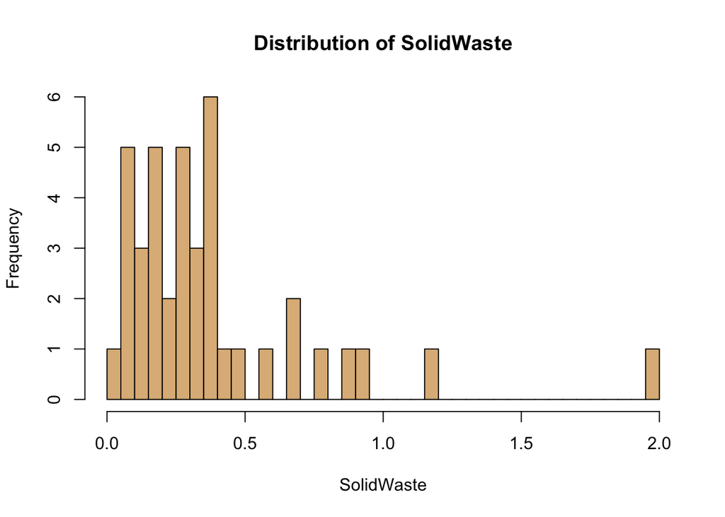

```r
library(e1071)
hist(waste$SolidWaste, breaks = 30, main = "Distribution of SolidWaste", xlab = "SolidWaste", col = "burlywood" )
```

```r
waste$SolidWaste <- as.numeric(waste$SolidWaste)
shapiro.test(waste$SolidWaste)
```

```
##
##  Shapiro-Wilk normality test
##
## data:  waste$SolidWaste
## W = 0.73803, p-value = 4.348e-07
```

```r
skewness(waste$SolidWaste)
```

```
## [1] 2.424377
```

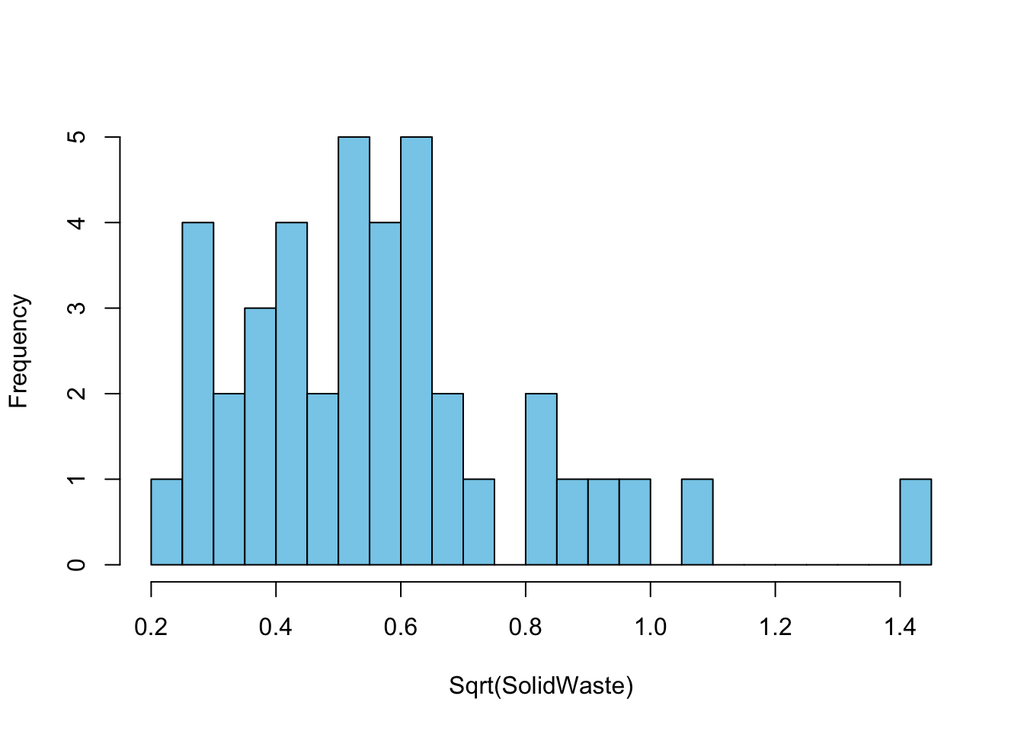

```r
hist(sqrt(waste$SolidWaste), breaks=30, main="", xlab="Sqrt(SolidWaste)", col = "skyblue")
```

```r
waste$SolidWaste <- as.numeric(waste$SolidWaste)
shapiro.test(sqrt(waste$SolidWaste))
```

```
##
##  Shapiro-Wilk normality test
##
## data:  sqrt(waste$SolidWaste)
## W = 0.9132, p-value = 0.004737
```

```r
skewness(sqrt(waste$SolidWaste))
```

```
## [1] 1.184919
```

Next, we apply a log transformation to the “SolidWaste” variable and observe that it better satisfies the normality assumption.

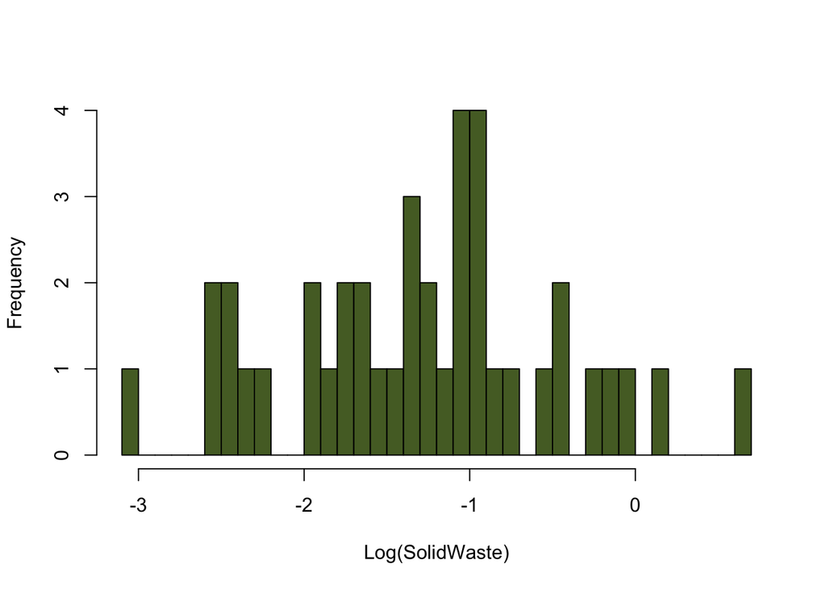

```r
hist(log(waste$SolidWaste), breaks=30, main="", xlab="Log(SolidWaste)", col = "darkolivegreen")
```

```r
waste$SolidWaste <- as.numeric(waste$SolidWaste)
shapiro.test(log(waste$SolidWaste))
```

```
##
##  Shapiro-Wilk normality test
##
## data:  log(waste$SolidWaste)
## W = 0.98884, p-value = 0.9574
```

```r
skewness(log(waste$SolidWaste))
```

```
## [1] 0.06997491
```

### Multiple Linear Regression

We proceed with a multiple linear regression (MLR) model using the log-transformed “SolidWaste” as the response variable. The model includes predictor variables: “Land,” “Metals,” “Trucking,” “Retail,” and “Restaurants.”

```r
waste$SolidWaste <- log(waste$SolidWaste)
mod.waste <- lm(SolidWaste ~ Land + Metals + Trucking + Retail + Restaurants, data = waste)
summary(mod.waste)
```

```
##
## Call:
## lm(formula = SolidWaste ~ Land + Metals + Trucking + Retail +
##     Restaurants, data = waste)
##
## Residuals:
##      Min       1Q   Median       3Q      Max
## -1.00085 -0.21602 -0.01193  0.25561  1.09351
##
## Coefficients:
##               Estimate Std. Error t value Pr(>|t|)
## (Intercept) -1.860e+00  1.034e-01 -17.984  < 2e-16 ***
## Land        -7.576e-05  5.846e-05  -1.296   0.2038
## Metals       1.191e-03  5.016e-04   2.374   0.0234 *
## Trucking    -1.266e-04  2.890e-04  -0.438   0.6642
## Retail      -3.206e-03  1.228e-03  -2.610   0.0134 *
## Restaurants  3.752e-02  7.447e-03   5.038 1.53e-05 ***
## ---
## Signif. codes:  0 '***' 0.001 '**' 0.01 '*' 0.05 '.' 0.1 ' ' 1
##
## Residual standard error: 0.4911 on 34 degrees of freedom
## Multiple R-squared:  0.6841, Adjusted R-squared:  0.6376
## F-statistic: 14.72 on 5 and 34 DF,  p-value: 1.073e-07
```

The model exhibits extremely small p-values, indicating a strong relationship between the response variable and the explanatory variables. The high multiple R-squared value (68.41%) suggests that 68.41% of the variation in the response variable is explained by the predictors. The coefficients reveal both positive and negative correlations between the variables.

**Estimate (Coefficient):** The “Estimate” column represents the estimated coefficients for each predictor variable in your MLR model. These coefficients tell you how much the mean of the response variable (SolidWaste) is expected to change for a one-unit change in each predictor variable while holding all other variables constant.

**Std. Error:** The “Std. Error” column shows the standard errors associated with each coefficient estimate. These standard errors quantify the amount of variability in the coefficient estimate due to random sampling. Smaller standard errors indicate more precise estimates.

**t-value:** The “t value” is calculated by dividing the coefficient estimate by its standard error. It measures how many standard errors the coefficient estimate is away from zero. A higher absolute t-value indicates a more significant relationship between the predictor variable and the response variable.

**Pr(>|t|):** The “Pr(>|t|)” column represents the p-value associated with the t-value. It tells you the probability of observing a t-value as extreme as, or more extreme than, the one you have in your sample if there is no true relationship between the predictor variable and the response variable. Smaller p-values (typically less than 0.05) indicate statistical significance.

Now, let’s interpret each coefficient in your model:

- **Intercept:** The intercept represents the expected value of SolidWaste when all predictor variables are zero. In your case, the intercept is -1.860e+00.
- **Land:** The coefficient for the “Land” variable is -7.576e-05. It suggests that for a one-unit increase in “Land,” the expected value of SolidWaste decreases by -7.576e-05, but it is not statistically significant because the p-value (0.2038) is greater than the typical significance level of 0.05.
- **Metals:** The coefficient for the “Metals” variable is 1.191e-03. It suggests that for a one-unit increase in “Metals,” the expected value of SolidWaste increases by 1.191e-03, and this effect is statistically significant because the p-value (0.0234) is less than 0.05.
- **Trucking:** The coefficient for the “Trucking” variable is -1.266e-04. It suggests that for a one-unit increase in “Trucking,” the expected value of SolidWaste decreases by -1.266e-04. However, this effect is not statistically significant because the p-value (0.6642) is much greater than 0.05.
- **Retail:** The coefficient for the “Retail” variable is -3.206e-03. It suggests that for a one-unit increase in “Retail,” the expected value of SolidWaste decreases by -3.206e-03, and this effect is statistically significant (p-value = 0.0134).
- **Restaurants:** The coefficient for the “Restaurants” variable is 3.752e-02. It suggests that for a one-unit increase in “Restaurants,” the expected value of SolidWaste increases by 3.752e-02, and this effect is highly statistically significant (p-value < 0.0001).

### Residual Analysis

The residuals of the model are examined to ensure normality. A quantile-quantile (QQ) plot and a Shapiro-Wilk test confirm the normality of the residuals.

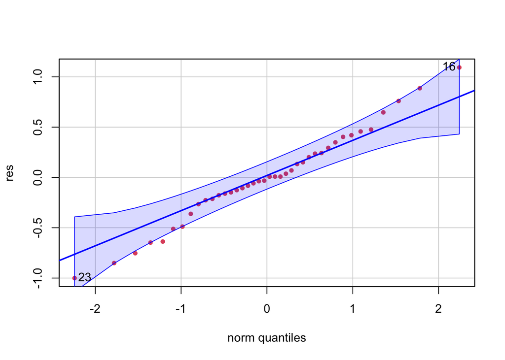

```
## [1] 16 23
```

```r
res <- residuals(mod.waste)
car::qqPlot(res, main = NA, pch = 19, col = 2, cex = 0.7)
```

```r
skew <- skewness(res)
cat("Skewness of the residuals: ", skew)
```

```
## Skewness of the residuals:  0.06108552
```

```r
shapiro.test(res)
```

```
##
##  Shapiro-Wilk normality test
##
## data:  res
## W = 0.98753, p-value = 0.9318
```

### Detecting Outliers and Leverage Points

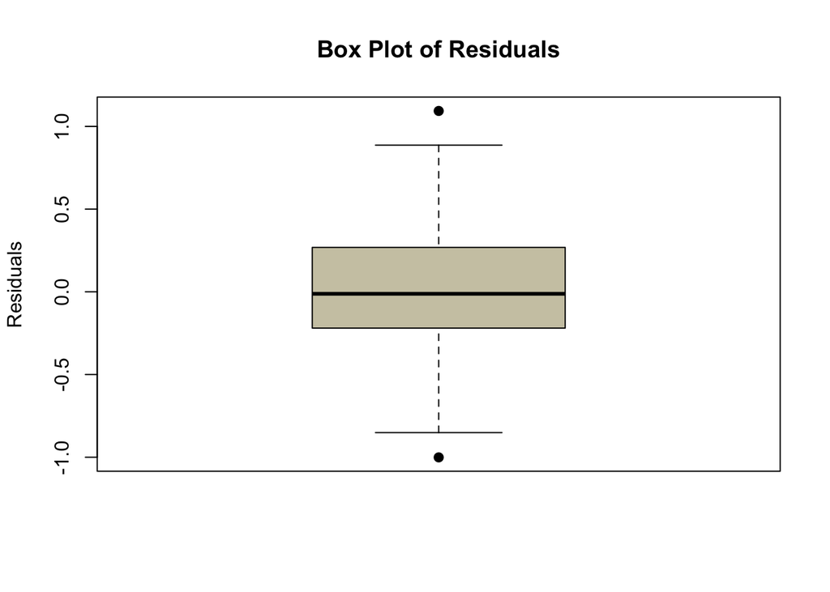

```r
boxplot(res, main = "Box Plot of Residuals", ylab = "Residuals", col = "cornsilk3", pch = 19)
```

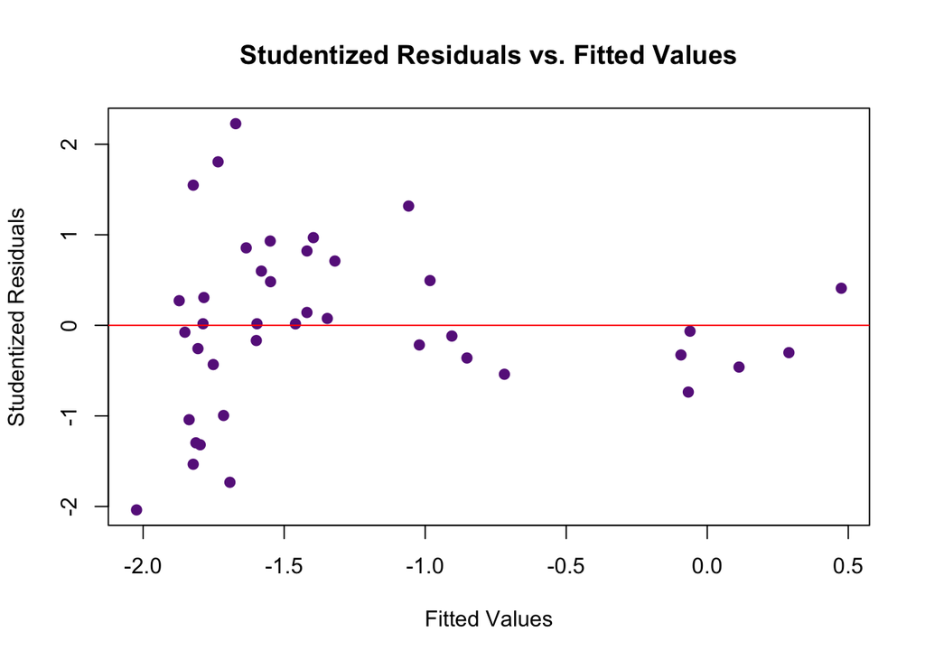

```r
sigma_residuals <- sigma(mod.waste)
studentized_residuals <- res / sigma_residuals
plot(fitted(mod.waste), studentized_residuals, xlab = "Fitted Values", ylab = "Studentized Residuals", main = "Studentized Residuals vs. Fitted Values", col = "darkorchid4", pch = 19)
abline(h = 0, col = "red")
```

```r
extpts <- which(abs(residuals(mod.waste)) > 3 * sd(residuals(mod.waste)))
extpts
```

```
## named integer(0)
```

Additionally, leverage points, which represent the influence of explanatory variables, are identified.

```r
n <- nrow(waste)
p <- ncol(waste) - 1
(hilev <- which(influence(mod.waste)$hat > max(2 * (p + 1) / n, 0.5)))
```

```
##  2 15 31 40
##  2 15 31 40
```

### Checking for Multicollinearity

The variance inflation factor (VIF) is employed to assess multicollinearity between the explanatory variables. VIF values less than 9.31019 indicate independence among variables.

```r
library("olsrr")
vif_values <- car::vif(mod.waste)
vif_values
```

```
##        Land      Metals    Trucking      Retail Restaurants
##    1.415870    5.625816    6.786948    8.310634    7.712421
```

Ridge Regression We apply ridge regression to the dataset, which involves regularization using the lambda parameter. Ridge regression helps mitigate multicollinearity and overfitting.

```r
library(glmnet)
pred.mat <- as.matrix(waste) # predictors
resp <- waste$SolidWaste # response

mod.ridge.1 <- glmnet(pred.mat, resp, alpha = 0, standardize = FALSE)
(lambda.m <- mod.ridge.1$lambda[100])
```

```
## [1] 29.6761
```

```r
coef(mod.ridge.1, s = lambda.m)
```

```
## 7 x 1 sparse Matrix of class "dgCMatrix"
##                        s1
## (Intercept) -1.800921e+00
## Land        -4.777588e-05
## Metals       1.114301e-03
## Trucking    -1.426075e-04
## Retail      -1.752675e-03
## Restaurants  2.774317e-02
## SolidWaste   6.576178e-03
```

To determine the optimal lambda value, we employ 10-fold cross-validation and visualize the results.

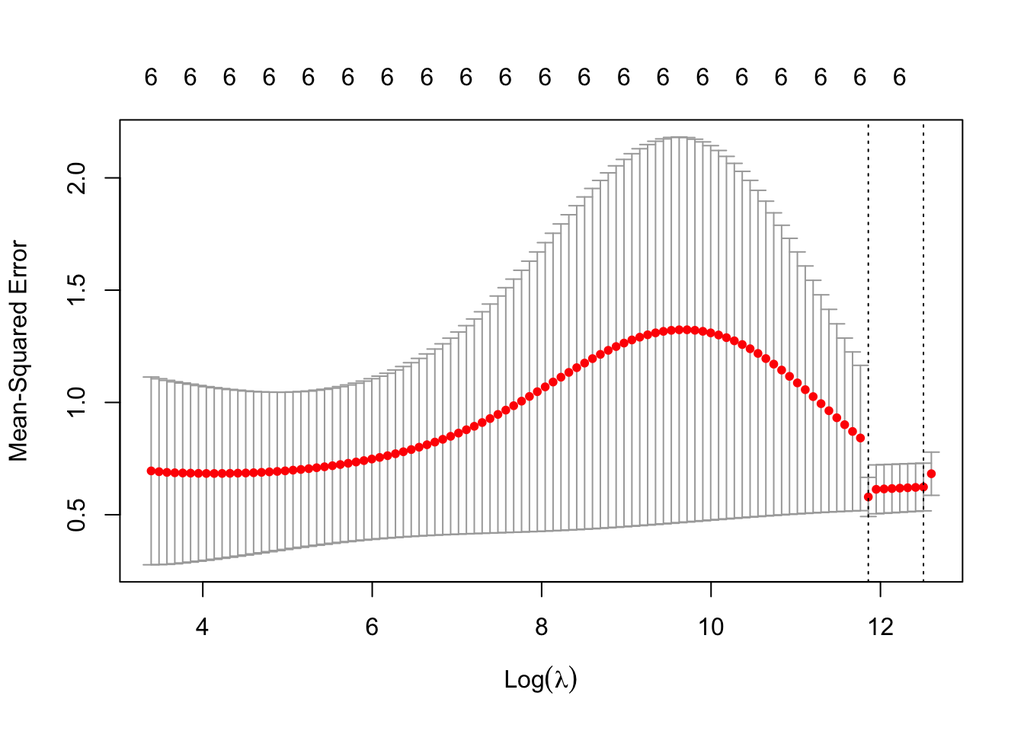

```r
cvfit.ridge <- cv.glmnet(pred.mat, resp, alpha = 0, standardize = FALSE, type.measure = "mse", nfolds = 10)
plot(cvfit.ridge)
```

```r
cvfit.ridge$lambda.min
```

```
## [1] 140985.5
```

The minimum lambda value results in the following coefficients:

```r
coef(cvfit.ridge, s = "lambda.min")
```

```
## 7 x 1 sparse Matrix of class "dgCMatrix"
##                        s1
## (Intercept) -1.468081e+00
## Land         3.924454e-05
## Metals       1.541742e-04
## Trucking     3.067384e-04
## Retail       3.096826e-04
## Restaurants  6.814056e-05
## SolidWaste   2.876719e-06
```

### Conclusion

In this analysis, we explored the Solid Waste dataset, examined normality, performed multiple linear regression, analyzed residuals, and investigated outliers and leverage points. We also checked for multicollinearity using VIF and applied ridge regression to the data. These steps provide valuable insights into the relationships and predictive power of the variables within the dataset.